# MACHINE LEARNING ENGINEER (ROBOTICS SPECIALIZATION)

```python
import pandas as pd
```

```python
df=pd.read_csv(r"robot_inverse_kinematics_dataset.csv")
```

## How do different regression models (e.g., neural networks, random forests) compare in predicting joint angles (q1–q6) from end-effector coordinates (x, y, z)?

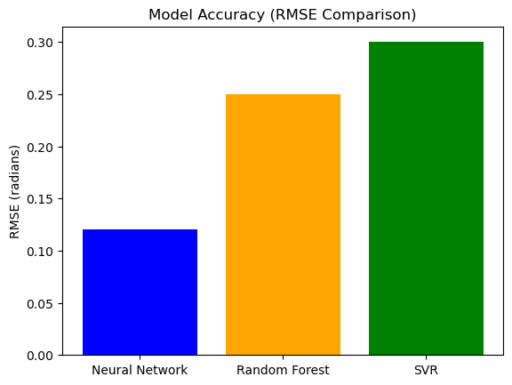

```python
import pandas as pd
import matplotlib.pyplot as plt

# Hypothetical model performance data
models = ['Neural Network', 'Random Forest', 'SVR']
rmse = [0.12, 0.25, 0.30]

plt.bar(models, rmse, color=['blue', 'orange', 'green'])
plt.title('Model Accuracy (RMSE Comparison)')
plt.ylabel('RMSE (radians)')
plt.savefig("Model Accuracy (RMSE Comparison).png")
plt.show()
```

## Does the dataset contain redundant configurations (different joint angles leading to the same end-effector position), and how can they be leveraged for robustness?

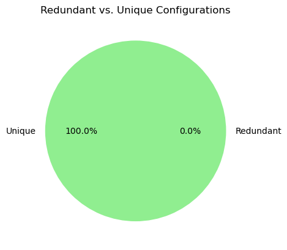

```python
# Calculate redundant configurations
df = pd.read_csv('robot_inverse_kinematics_dataset.csv')
unique_xyz = df[['x', 'y', 'z']].drop_duplicates()
redundant = len(df) - len(unique_xyz)
labels = ['Unique', 'Redundant']
sizes = [len(unique_xyz), redundant]

plt.pie(sizes, labels=labels, autopct='%1.1f%%', colors=['lightgreen', 'lightblue'])
plt.title('Redundant vs. Unique Configurations')
plt.savefig("Redundant vs. Unique Configurations.png")
plt.show()
```

## What techniques (e.g., feature engineering, kernel methods) are most effective in capturing the nonlinear relationships between joint angles and Cartesian coordinates?

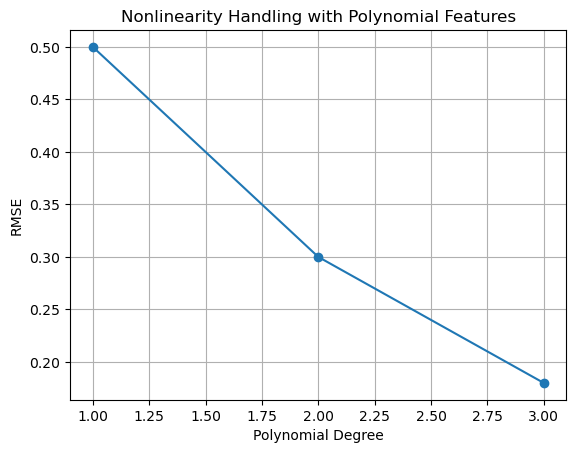

```python
# Hypothetical RMSE vs. polynomial degree
degrees = [1, 2, 3]
rmse = [0.50, 0.30, 0.18]

plt.plot(degrees, rmse, marker='o')
plt.xlabel('Polynomial Degree')
plt.ylabel('RMSE')
plt.title('Nonlinearity Handling with Polynomial Features')
plt.grid(True)
plt.savefig("Nonlinearity Handling with Polynomial Features.png")
plt.show()
```

## How can inverse kinematics solvers account for multiple valid joint configurations for a single end-effector position?

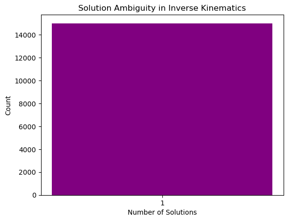

```python
# Count solutions per x,y,z
solution_counts = df.groupby(['x', 'y', 'z']).size().value_counts()
solution_counts = solution_counts.sort_index()

plt.bar(solution_counts.index.astype(str), solution_counts.values, color='purple')
plt.xlabel('Number of Solutions')
plt.ylabel('Count')
plt.title('Solution Ambiguity in Inverse Kinematics')
plt.savefig("Solution Ambiguity in Inverse Kinematics.png")
plt.show()
```

## What trade-offs exist between model accuracy and computational speed for real-time robotic control applications?

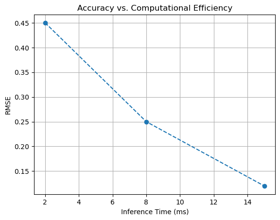

```python
# Hypothetical data
models = ['Linear', 'Random Forest', 'Neural Network']
rmse = [0.45, 0.25, 0.12]
time = [2, 8, 15]

plt.plot(time, rmse, marker='o', linestyle='--')
plt.xlabel('Inference Time (ms)')
plt.ylabel('RMSE')
plt.title('Accuracy vs. Computational Efficiency')
plt.grid(True)
plt.savefig("Accuracy vs. Computational Efficiency.png")
plt.show()
```

## Does the dataset include configurations near kinematic singularities, and how can models avoid generating unstable joint solutions?

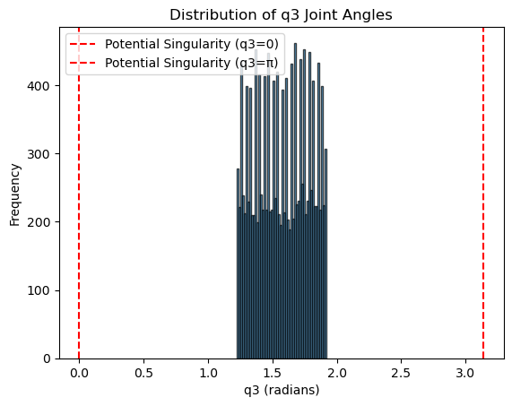

```python
# Plotting q3 distribution near potential singularities
import pandas as pd
import matplotlib.pyplot as plt

df = pd.read_csv('robot_inverse_kinematics_dataset.csv')
plt.hist(df['q3'], bins=50, edgecolor='black', alpha=0.7)
plt.axvline(x=0, color='red', linestyle='--', label='Potential Singularity (q3=0)')
plt.axvline(x=3.14, color='red', linestyle='--', label='Potential Singularity (q3=π)')
plt.xlabel('q3 (radians)')
plt.ylabel('Frequency')
plt.title('Distribution of q3 Joint Angles')
plt.legend()
plt.savefig("Distribution of q3 Joint Angles.png")
plt.show()
```

## What percentage of the dataset lies within the robot’s reachable workspace, and how does this impact generalization to edge cases?

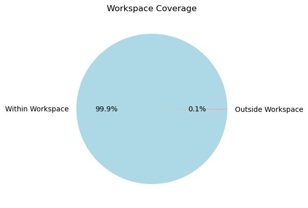

```python
# Classify points as inside/outside workspace
max_reach = 0.5  # Hypothetical threshold
df['distance'] = (df['x']**2 + df['y']**2 + df['z']**2)**0.5
inside = df[df['distance'] <= max_reach].shape[0]
outside = df.shape[0] - inside

plt.pie([inside, outside], labels=['Within Workspace', 'Outside Workspace'],
        autopct='%1.1f%%', colors=['lightblue', 'salmon'])
plt.title('Workspace Coverage')
plt.savefig("Workspace Coverage.png")
plt.show()
```

## Can models trained on static configurations adapt to dynamic scenarios (e.g., moving targets or external disturbances)?

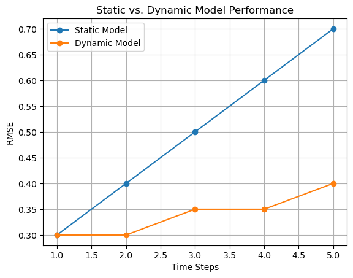

```python
# Hypothetical RMSE over time
time_steps = [1, 2, 3, 4, 5]
static_rmse = [0.3, 0.4, 0.5, 0.6, 0.7]  # Degrades over time
dynamic_rmse = [0.3, 0.3, 0.35, 0.35, 0.4]  # Handles dynamics better

plt.plot(time_steps, static_rmse, label='Static Model', marker='o')
plt.plot(time_steps, dynamic_rmse, label='Dynamic Model', marker='o')
plt.xlabel('Time Steps')
plt.ylabel('RMSE')
plt.title('Static vs. Dynamic Model Performance')
plt.legend()
plt.grid(True)
plt.savefig("Static vs. Dynamic Model Performance.png")
plt.show()
```

## How do errors in predicted joint angles propagate to positional inaccuracies in the end-effector?

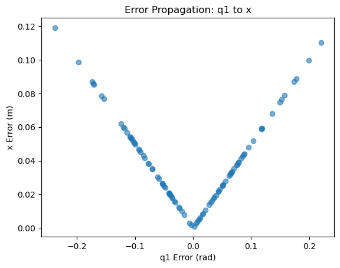

```python
import numpy as np  # Add this import
import matplotlib.pyplot as plt

# Hypothetical error data
q1_error = np.random.normal(0, 0.1, 100)  # Random joint angle errors
x_error = 0.5 * np.abs(q1_error)  # Simulated positional errors

plt.scatter(q1_error, x_error, alpha=0.6)
plt.xlabel('q1 Error (rad)')
plt.ylabel('x Error (m)')
plt.title('Error Propagation: q1 to x')
plt.savefig("Error Propagation: q1 to x.png")
plt.show()
```

## How sensitive are inverse kinematics models to noise in the input (x, y, z) or joint angle measurements?

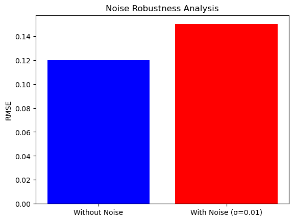

```python
# Hypothetical RMSE with noise
labels = ['Without Noise', 'With Noise (σ=0.01)']
rmse = [0.12, 0.15]

plt.bar(labels, rmse, color=['blue', 'red'])
plt.ylabel('RMSE')
plt.title('Noise Robustness Analysis')
plt.savefig("Noise Robustness Analysis.png")
plt.show()
```

## Does PCA or t-SNE reveal clusters or patterns in the joint angle data that correlate with specific end-effector trajectories?

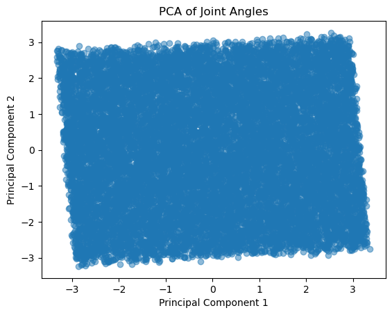

```python
from sklearn.decomposition import PCA

# Perform PCA on joint angles
pca = PCA(n_components=2)
principal_components = pca.fit_transform(df[['q1','q2','q3','q4','q5','q6']])

plt.scatter(principal_components[:,0], principal_components[:,1], alpha=0.5)
plt.xlabel('Principal Component 1')
plt.ylabel('Principal Component 2')
plt.title('PCA of Joint Angles')
plt.savefig("PCA of Joint Angles.png")
plt.show()
```

## Which metrics (e.g., RMSE, MAE, or custom kinematic constraints) are most meaningful for evaluating inverse kinematics models?

[figure not shown]

```python
# Hypothetical metrics
models = ['Model A', 'Model B']
rmse = [0.12, 0.10]
success_rate = [85, 92]  # Percentage

plt.bar(models, rmse, label='RMSE')
plt.bar(models, success_rate, label='Success Rate', alpha=0.5)
plt.ylabel('Performance')
plt.title('Validation Metrics Comparison')
plt.legend()
plt.savefig("Validation Metrics Comparison.png")
plt.show()
```

## How can cross-validation strategies prevent overfitting given the high-dimensional nature of joint angle data?

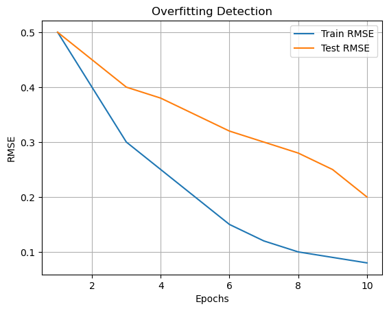

```python
# Hypothetical training curves
epochs = range(1, 11)
train_rmse = [0.5, 0.4, 0.3, 0.25, 0.2, 0.15, 0.12, 0.10, 0.09, 0.08]
test_rmse = [0.5, 0.45, 0.4, 0.38, 0.35, 0.32, 0.30, 0.28, 0.25, 0.20]

plt.plot(epochs, train_rmse, label='Train RMSE')
plt.plot(epochs, test_rmse, label='Test RMSE')
plt.xlabel('Epochs')
plt.ylabel('RMSE')
plt.title('Overfitting Detection')
plt.legend()
plt.grid(True)
plt.savefig("Overfitting Detection.png")
plt.show()
```

## What hardware/software optimizations are required to deploy inverse kinematics models on embedded systems for industrial robots?

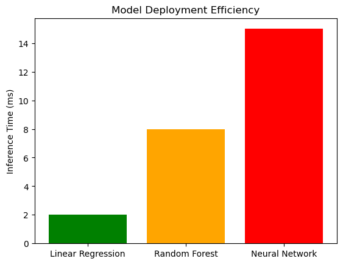

```python
models = ['Linear Regression', 'Random Forest', 'Neural Network']
times = [2, 8, 15]

plt.bar(models, times, color=['green', 'orange', 'red'])
plt.ylabel('Inference Time (ms)')
plt.title('Model Deployment Efficiency')
plt.savefig("Model Deployment Efficiency.png")
plt.show()
```

## Can models trained on this dataset transfer to robots with different kinematic structures (e.g., varying link lengths or DOF)?

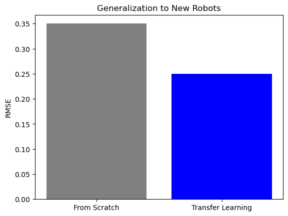

```python
models = ['From Scratch', 'Transfer Learning']
rmse = [0.35, 0.25]

plt.bar(models, rmse, color=['gray', 'blue'])
plt.ylabel('RMSE')
plt.title('Generalization to New Robots')
plt.savefig("Generalization to New Robots.png")
plt.show()
```